# R Notebook

```r
results <- read_csv(file=file.path(getwd(), "compiled_results.csv"))
```

```
indexing compiled_results.csv [==============================] 576.50MB/s, eta:  0s
```

```r
results$DKNN_method <- factor(results$DKNN_method, levels = c("None", "Conformal", "Normal"))
results
```

| Dataset | Model | Logits | DKNN_method | eval_accuracy | predict_accuracy | eval_f1 | eval_f1-positive | eval_f1-negative | predict_f1 | predict_f1-positive | predict_f1-negative | eval_precision | predict_precision | eval_recall | predict_recall | eval_confidence | predict_confidence |
| --- | --- | --- | --- | --- | --- | --- | --- | --- | --- | --- | --- | --- | --- | --- | --- | --- | --- |
| twitter-hate | Bart-large | Scores | None | 0.9114223 | 0.9069905 | 0.4039761 | 0.4039761 | 0.9521560 | 0.4037879 | 0.4037879 | 0.9495610 | 0.2889647 | 0.2904632 | 0.6710700 | 0.6621118 | 0.8563927 | 0.8530719 |
| twitter-hate | Bart-large | Conformal P-value | Conformal | 0.9593453 | 0.9562725 | 0.2338530 | 0.2338530 | 0.9791186 | 0.2127660 | 0.2127660 | 0.9775117 | 0.7446809 | 0.7407407 | 0.1387054 | 0.1242236 | 0.9502483 | 0.9473545 |
| twitter-hate | Bart-large | log-probability | Normal | 0.9593453 | 0.9562725 | 0.2338530 | 0.2338530 | 0.9791186 | 0.2127660 | 0.2127660 | 0.9775117 | 0.7446809 | 0.7407407 | 0.1387054 | 0.1242236 | 0.9327814 | 0.9295150 |
| twitter-hate | DeBerta-large | Scores | None | 0.9414406 | 0.9394315 | 0.4288184 | 0.4288184 | 0.9691383 | 0.4333886 | 0.4333886 | 0.9680057 | 0.3803681 | 0.3904382 | 0.4914135 | 0.4869565 | 0.9372396 | 0.9344818 |
| twitter-hate | DeBerta-large | Conformal P-value | Conformal | 0.9598180 | 0.9572180 | 0.2811839 | 0.2811839 | 0.9793313 | 0.2701613 | 0.2701613 | 0.9779631 | 0.7037037 | 0.7165775 | 0.1756935 | 0.1664596 | 0.9497099 | 0.9467836 |
| twitter-hate | DeBerta-large | log-probability | Normal | 0.9598180 | 0.9572180 | 0.2811839 | 0.2811839 | 0.9793313 | 0.2701613 | 0.2701613 | 0.9779631 | 0.7037037 | 0.7165775 | 0.1756935 | 0.1664596 | 0.9351903 | 0.9315670 |
| toxigen | Bart-large | Scores | None | 0.8510101 | 0.8042553 | 0.8527209 | 0.8527209 | 0.8492591 | 0.8311927 | 0.8311927 | 0.7670886 | 0.8868120 | 0.8952569 | 0.8211538 | 0.7756849 | 0.8061478 | 0.7637441 |
| toxigen | Bart-large | Conformal P-value | Conformal | 0.8358586 | 0.8085106 | 0.8460445 | 0.8460445 | 0.8242293 | 0.8369565 | 0.8369565 | 0.7680412 | 0.8338002 | 0.8884615 | 0.8586538 | 0.7910959 | 0.4667725 | 0.3947367 |
| toxigen | Bart-large | log-probability | Normal | 0.8358586 | 0.8085106 | 0.8460445 | 0.8460445 | 0.8242293 | 0.8369565 | 0.8369565 | 0.7680412 | 0.8338002 | 0.8884615 | 0.8586538 | 0.7910959 | 0.7314537 | 0.6477983 |
| toxigen | DeBerta-large | Scores | None | 0.8434343 | 0.8329787 | 0.8539114 | 0.8539114 | 0.8313384 | 0.8647717 | 0.8647717 | 0.7816412 | 0.8373383 | 0.8700173 | 0.8711538 | 0.8595890 | 0.8373349 | 0.8263316 |

[output cut: 2 more lines]

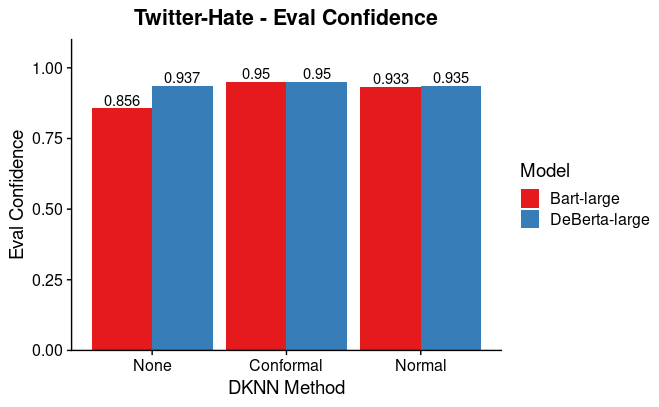

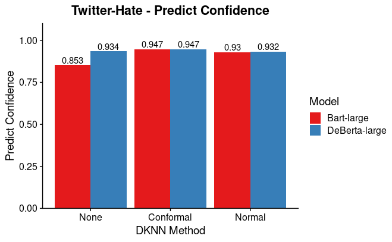

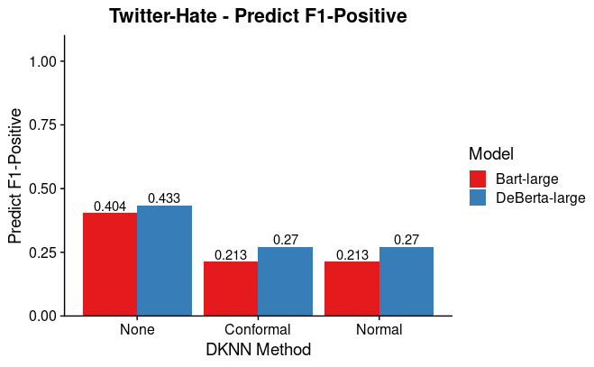

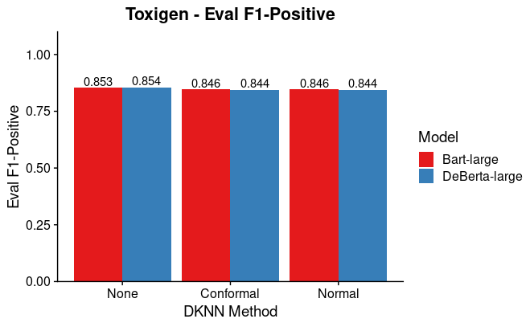

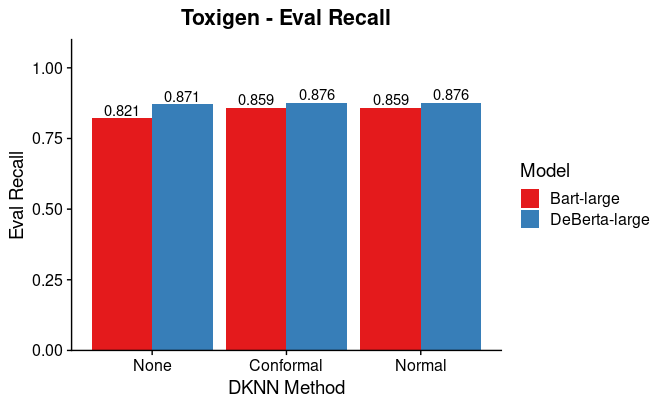

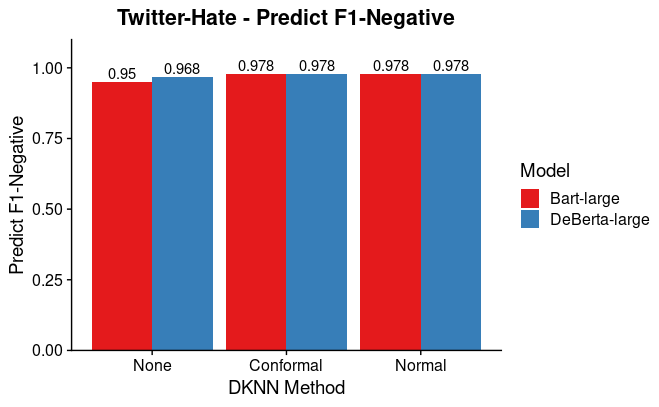

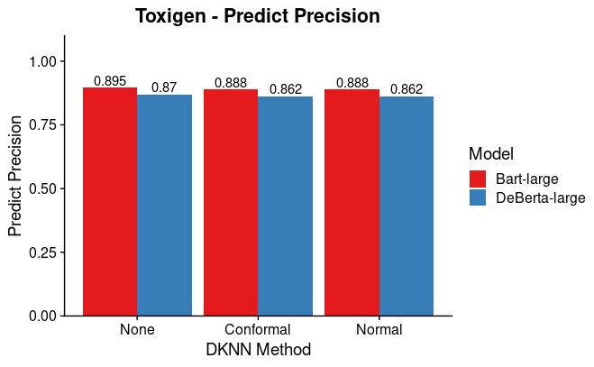

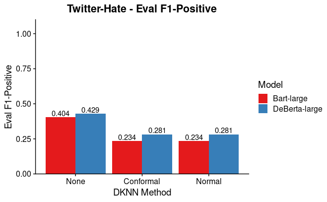

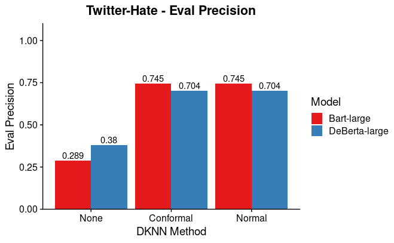

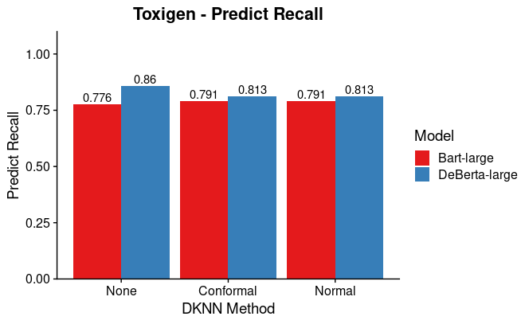

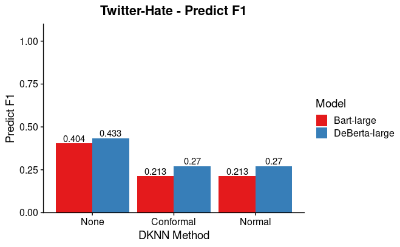

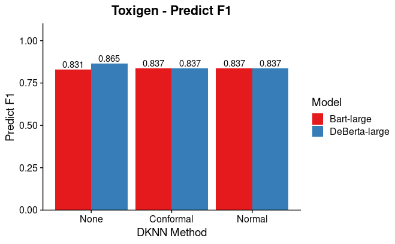

[16 more figures not shown]

```r
plot_bars <- function(df, dataset_name, col_name) {
  col_name_pretty <- gsub("_", " ", col_name) %>% str_to_title()
  ggplot(df, aes(fill=Model, y=get(col_name), x=DKNN_method)) +
      geom_bar(position="dodge", stat="identity") +
      scale_y_continuous(expand = expansion(mult = c(0, 0.1), add = c(0, 0)),
                         limits = c(0, 1), name = col_name_pretty) +
      scale_x_discrete(name = "DKNN Method") +
      scale_fill_brewer(palette = "Set1") +
      ggtitle(paste(str_to_title(dataset_name), "-", col_name_pretty)) +
      geom_text(aes(label=round(get(col_name), 3)),
                position=position_dodge(width=0.9), vjust=-0.25) +
      theme_cowplot() +
      theme(
        plot.title = element_text(hjust = 0.5)
      )
}
numeric_columns <- results %>% select_if(is_double) %>% colnames()
for (dataset_name in results$Dataset %>% unique()) {
  res_subset = results %>% filter(Dataset == dataset_name)
  for (col_name in numeric_columns) {
    col_name_pretty <- gsub("_", " ", col_name) %>% str_to_title()
    # for each dataset, compare model + method on multiple metrics
    print(plot_bars(res_subset, dataset_name, col_name))
  }
}
```

Not too clear on the interpretation of overall confidence score: higher = more faithful?

Most metrics relatively the same across models, deBerta slightly better than bart-large for both datasets.

From the graph results, it appears that DKNN for the most part do not degrade model performance, but could be significant for Founta F1 (does not happen for Toxigen).

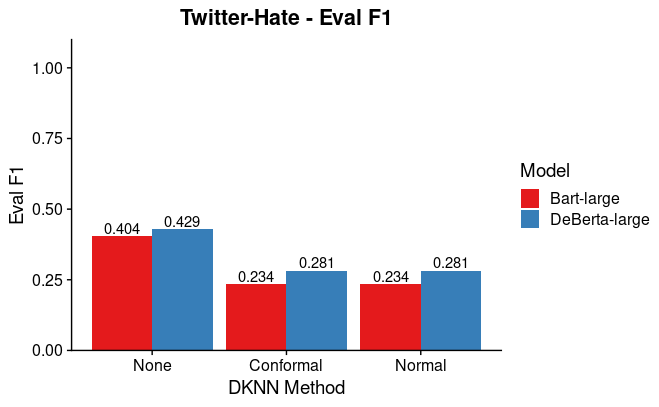

```r
plot_bars(results %>% filter(Dataset == "twitter-hate"), "twitter-hate", "eval_f1")
```

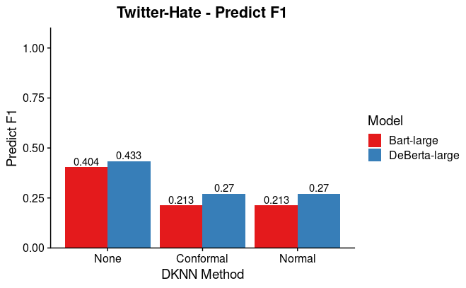

```r
plot_bars(results %>% filter(Dataset == "twitter-hate"), "twitter-hate", "predict_f1")
```

Interestingly, this is because for Founta et. al. only, DKNN seems to drastically decrease recall (TP/Pred P, here recall refers to the percentage of all tweets that the model thinks are toxic and is actually toxic; fraction of relevant instances among the retrieved instances) in favor of precision (TP/ True P, here the percentage of all tweets that are toxic and actually classified as toxic; fraction of relevant instances that were retrieved).

This happens for both the Eval and Test set for Founta.

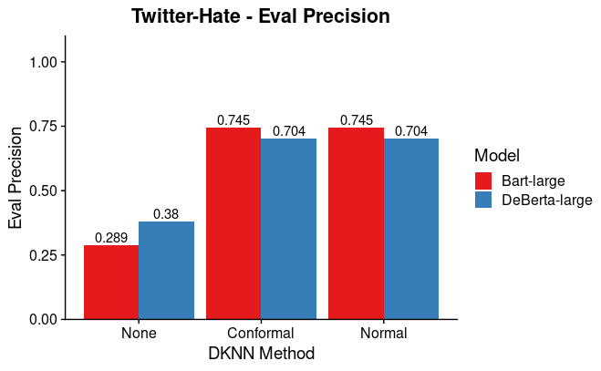

```r
plot_bars(results %>% filter(Dataset == "twitter-hate"), "twitter-hate", "eval_precision")
```

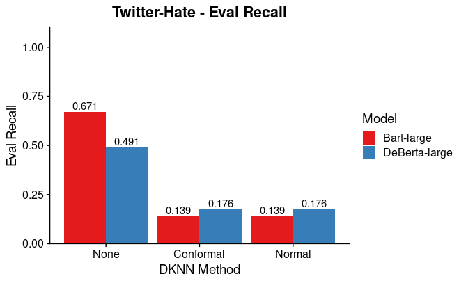

```r
plot_bars(results %>% filter(Dataset == "twitter-hate"), "twitter-hate", "eval_recall")
```

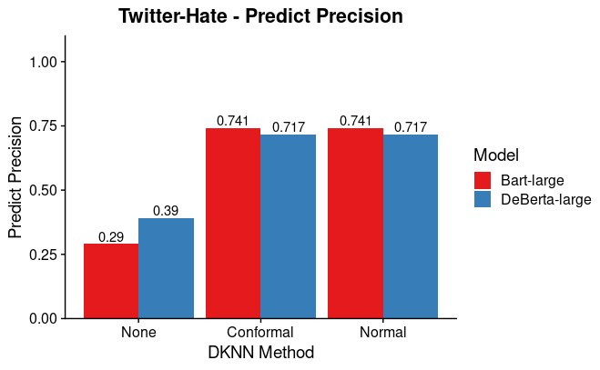

```r
plot_bars(results %>% filter(Dataset == "twitter-hate"), "twitter-hate", "predict_precision")
```

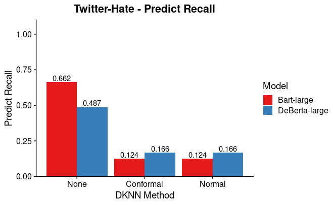

```r
plot_bars(results %>% filter(Dataset == "twitter-hate"), "twitter-hate", "predict_recall")
```

## Explore Neighbors

1. DKNN Conformal or Normal results in the same nearest neighbors (as they should), since the only difference is the way logits are computed (conformal p-values using nonconformity vs. straight log probability from label counts)

```r
founta_bart_large_eval_conformal
```

| Tweet | label | eval_idx | train_idx |
| --- | --- | --- | --- |
| if you are into the outdoors and survival check this out https tco xztmpt mm https tco qglfux dv | 0 | 0 | 47322 |
| if you are into the outdoors and survival check this out https tco xztmpt mm https tco awso tiybq | 0 | 0 | 27579 |
| you want the ability to be free from other people s demands to more for aquarius https tco xv hxbyf f | 0 | 0 | 46546 |
| me and my bestfriend go through it but the bond is strong she s here to stay forever https tco t cpbagwz | 0 | 0 | 39085 |
| with the gorgeous lenaisapeach in my horny stepsister just for you the fans https tco xfjq x vk | 0 | 0 | 3165 |
| there are lots of things to do around the house and you can t more for pisces https tco wuqldnil f | 0 | 0 | 27484 |
| kilovh apparently the proof we learned is folklore https tco h rvuwafms https tco x a z dm | 0 | 0 | 1868 |
| rt thcchicks find you a bad bitch who smokes and you ve won at life https tco ocrmd yfq | 0 | 0 | 1289 |
| i wanna be fucked go to the link https tco kzdek fbro https tco rxwgf afqq | 0 | 0 | 7295 |
| you might respond to a moral dilemma at work by remaining quie more for cancer https tco fepxrfhq x | 0 | 0 | 35693 |

[output cut: 990 more lines]

```r
founta_bart_large_eval_normal
```

| Tweet | label | eval_idx | train_idx |
| --- | --- | --- | --- |
| if you are into the outdoors and survival check this out https tco xztmpt mm https tco qglfux dv | 0 | 0 | 47322 |
| if you are into the outdoors and survival check this out https tco xztmpt mm https tco awso tiybq | 0 | 0 | 27579 |
| you want the ability to be free from other people s demands to more for aquarius https tco xv hxbyf f | 0 | 0 | 46546 |
| me and my bestfriend go through it but the bond is strong she s here to stay forever https tco t cpbagwz | 0 | 0 | 39085 |
| with the gorgeous lenaisapeach in my horny stepsister just for you the fans https tco xfjq x vk | 0 | 0 | 3165 |
| there are lots of things to do around the house and you can t more for pisces https tco wuqldnil f | 0 | 0 | 27484 |
| kilovh apparently the proof we learned is folklore https tco h rvuwafms https tco x a z dm | 0 | 0 | 1868 |
| rt thcchicks find you a bad bitch who smokes and you ve won at life https tco ocrmd yfq | 0 | 0 | 1289 |
| i wanna be fucked go to the link https tco kzdek fbro https tco rxwgf afqq | 0 | 0 | 7295 |
| you might respond to a moral dilemma at work by remaining quie more for cancer https tco fepxrfhq x | 0 | 0 | 35693 |

[output cut: 990 more lines]

2. For two different models, they result in different neighbors (as expected)

```r
founta_deberta_large_eval_conformal <- neighbor_dfs[[2]]
founta_deberta_large_eval_conformal
```

| Tweet | label | eval_idx | train_idx |
| --- | --- | --- | --- |
| if you are into the outdoors and survival check this out https tco xztmpt mm https tco awso tiybq | 0 | 0 | 27579 |
| if you are into the outdoors and survival check this out https tco xztmpt mm https tco qglfux dv | 0 | 0 | 47322 |
| essential listening on scarcity and what it does to our behavior https tco x pejrbf https tco ny aru zj | 0 | 0 | 46487 |
| what are some habits you developed as a kid and carried into adulthood https tco xdkp z nw https tco jm hipamyl april | 0 | 0 | 14233 |
| this is how you become unattractive and you re not aware of it https tco txz f pa https tco nlyibnssqy | 0 | 0 | 34646 |
| we have the perception that juice is always healthier than soda https tco gs fu zesl https tco xwsihc gbq | 0 | 0 | 49500 |
| arriving in style how to make the perfect entrance to your wedding https tco cd jonhk https tco lmprhzd w | 0 | 0 | 12282 |
| i want to feel the cock inside your self i m there https tco lwu kas v https tco vevhjgsipi | 0 | 0 | 37411 |
| interested in a job in dallas tx this could be a great fit https tco dmv glcxt it hiring https tco py llonaot | 0 | 0 | 48812 |
| available now the lady of the forest by barbarabettis https tco izfrsmrk z https tco fhenp wu | 0 | 0 | 29581 |

[output cut: 990 more lines]

It's then natural to inquire: what are the % overlap/ how dissimilar are the nearest neighbors found between bart-large and deberta for the founta, toxigen dataset?

```r
compute_neighbor_overlap_per_example <- function(i, df1, df2) {
  set1 <- df1 %>% filter(eval_idx == i) %>% .$train_idx %>% unique()
  set2 <- df2 %>% filter(eval_idx == i) %>% .$train_idx %>% unique()
  intersection <- intersect(set1, set2)
  set1_perc <- length(intersection) / length(set1)
  set2_perc <- length(intersection) / length(set2)
  return(c(set1_perc, set2_perc))
}
```

```r
# takes soooo long, so use subsample instead
```

[output not shown]

```r
# N <- nrow(founta_eval)
N <- 100
res_matrix <- sapply(seq(1:N),
       function(i) compute_neighbor_overlap_per_example(
         i, founta_bart_large_eval_conformal,
         founta_deberta_large_eval_conformal)
       )
print(summary(res_matrix[1, 1:100])) # bart-large stats
```

```
   Min. 1st Qu.  Median    Mean 3rd Qu.    Max.
0.05319 0.12431 0.16775 0.18588 0.21451 0.62500
```

```r
print(summary(res_matrix[2, 1:100])) # deberta-large stats
```

```
   Min. 1st Qu.  Median    Mean 3rd Qu.    Max.
 0.0625  0.1502  0.2034  0.2163  0.2590  0.7407
```